# 4. 선형회귀

```python
import warnings
warnings.filterwarnings('ignore')

import pandas as pd
import numpy as np
import graphviz as gr
from matplotlib import style
import seaborn as sns
from matplotlib import pyplot as plt
style.use("ggplot")
import statsmodels.formula.api as smf
import matplotlib
from cycler import cycler

# default_cycler = (cycler(color=['0.3', '0.5', '0.7', '0.5']))

color=['0.3', '0.5', '0.7', '0.9']
linestyle=['-', '--', ':', '-.']
marker=['o', 'v', 'd', 'p']

# plt.rc('axes', prop_cycle=default_cycler)

gr.set_default_format("png");
```

## 04.01 선형회귀의 필요성

- 회귀분석은 인과추론의 핵심이자 가장 많이 사용되는 방법
- 회귀분석은 대부분의 패널 데이터 방법 (이중차분법 (DID), 이원고정효과 (TWFE), 머신러닝(이중/편향 제거)) 그리고 다른 식별 기법 (도구변수, 불연속 설계) 등 응용 방법론의 구성 요소

### 01. 모델이 필요한 이유

- 처치가 무작위 배정된 것 처럼 보이도록 변수를 보정하는 방법

$$ATE = E_x [E[Y | T=1, X=x] - E[Y|T=0, X=x]]$$ 에서 조건부 독립성 가정 ($Y_0, Y_1 \perp T|X$)이 만족되면 인과효과 식별 가능

- 하지만, 데이터를 특성 $X$에 따라서 여러 그룹으로 나누어야 함

  $\rightarrow$ 특성이 이산형이 아닌 연속형이라면?

  $\rightarrow$ **차원의 저주 가능성**

  $\rightarrow$ 공변량이 많을 때 보정 공식을 그대로 적용하면 데이터 희소성 문제 발생
- 차원의 저주에서 벗어나는 방법은 **잠재젹 결과를 선형회귀 같은 방식으로 모델링할 수 있다고 가정**하고

  **$X$로 정의된 각각의 셀을 내삽하고 외삽하는 것**

  $\rightarrow$ 결과변수를 $X$ 변수로 투영한 후, 이 투영된 값들을 바탕으로 실험군과 대조군을 비교

### 02. A/B 테스트와 회귀분석

> 온라인 스트리밍 회사의 추천 시스템 개선

> 추천 시스템이 스트리밍 서비스의 시청 시간을 늘릴 수 있는가?

> A/B 테스트 진행
1. 고객층을 대표할 일부 고객 표본 추출*
2. 표본에서 무작위로 1/3을 골라 새로운 추천 시스템 적용, 나머지는 이전 버전의 추천 시스템을 계속 적용
3. 한 달 후, 하루 평균 시청 시간 결과 수집

```python
import pandas as pd
import numpy as np
import statsmodels.formula.api as smf
```

```python
data = pd.read_csv("./data/rec_ab_test.csv")
data.head()
```

|  | recommender | age | tenure | watch_time |
| --- | --- | --- | --- | --- |
| 0 | challenger | 15 | 1 | 2.39 |
| 1 | challenger | 27 | 1 | 2.32 |
| 2 | benchmark | 17 | 0 | 2.74 |
| 3 | benchmark | 34 | 1 | 1.92 |
| 4 | benchmark | 14 | 1 | 2.47 |

- **추천 시스템의 버전이 무작위로 배정되었으므로, 평균 시청 시간의 단순한 비교만으로 ATE 추정 가능**

  $\rightarrow$ A/B 테스트 결과를 회귀분석으로 해석하면, 필요한 모든 추론 통계량을 얻을 수 있음
  - $challenger$는 새로운 추천 시스템이 적용되면 1, 그렇지 않으면 0
  - 새로운 버전의 효과는 $\beta_1$의 추정값인 $\hat{\beta_1)}$

$$WatchTime_i = \beta_0 + \beta_1 challenger_i + e_i$$

```python
result = smf.ols('watch_time ~ C(recommender)', data=data).fit()
result.summary().tables[1]
```

|  | coef | std err | t | P>\|t\| | [0.025 | 0.975] |
| --- | --- | --- | --- | --- | --- | --- |
| Intercept | 2.0491 | 0.058 | 35.367 | 0.000 | 1.935 | 2.163 |
| C(recommender)[T.challenger] | 0.1427 | 0.095 | 1.501 | 0.134 | -0.044 | 0.330 |

- 기존 버전 추천 시슽메을 사용했을 떄 고객이 하루 평균 2.04 시간 동안 스트리밍
- **ATE의 추정값 = $\hat{\beta_1}$ = 0.14시간 $\rightarrow$ 통계적으로 유의하지 않음**

```python
(data
 .groupby("recommender")
 ["watch_time"]
 .mean())
```

```
recommender
benchmark     2.049064
challenger    2.191750
Name: watch_time, dtype: float64
```

### 03. 회귀분석을 통한 보정

> 고객의 특성 (월급, 신용 점수 등), **고객의 신용한도(처치)**, 고객의 채무불이행 여부를 알려주는 결과변수의 데이터

```python
risk_data = pd.read_csv("./data/risk_data.csv")
risk_data.head()
```

|  | wage | educ | exper | married | credit_score1 | credit_score2 | credit_limit | default |
| --- | --- | --- | --- | --- | --- | --- | --- | --- |
| 0 | 950.0 | 11 | 16 | 1 | 500.0 | 518.0 | 3200.0 | 0 |
| 1 | 780.0 | 11 | 7 | 1 | 414.0 | 429.0 | 1700.0 | 0 |
| 2 | 1230.0 | 14 | 9 | 1 | 586.0 | 571.0 | 4200.0 | 0 |
| 3 | 1040.0 | 15 | 8 | 1 | 379.0 | 411.0 | 1500.0 | 0 |
| 4 | 1000.0 | 16 | 1 | 1 | 379.0 | 518.0 | 1800.0 | 0 |

- **처치 (`credit_limit`)은 연속형 변수**

  $\rightarrow$ ATE를 여러 처치 수준간의 표현하는 대신, 기대 결과 처치에 대한 도함수로 표현

  (**처치가 한 단위 증가할 때 결과가 얼마나 변할지에 대한 기댓값**)

$$ATE = \frac{\delta}{\delta t}E[y|t]$$

$$Default_i = \beta_0 + \beta_1 line_i + e_i$$

```python
model = smf.ols('default ~ credit_limit', data=risk_data).fit()
model.summary().tables[1]
```

|  | coef | std err | t | P>\|t\| | [0.025 | 0.975] |
| --- | --- | --- | --- | --- | --- | --- |
| Intercept | 0.2192 | 0.004 | 59.715 | 0.000 | 0.212 | 0.226 |
| credit_limit | -2.402e-05 | 1.16e-06 | -20.689 | 0.000 | -2.63e-05 | -2.17e-05 |

- **$\hat{\beta_1}$ : 신용 한도가 1달러 증가할 떄 채무불이행률이 얼마나 변할지에 대한 기댓값**
  - **신용 한도가 무작위로 배정되었다면, 인과적인 해석 가능**

    $\rightarrow$ **은행은 위험이 적은 고객에게 더 높은 한도를 주는 경향이 있기에 그렇지 않음**

    $\rightarrow$ **교란으로 인해 채무불이행률과 신용 한도가 음의 상관관계**

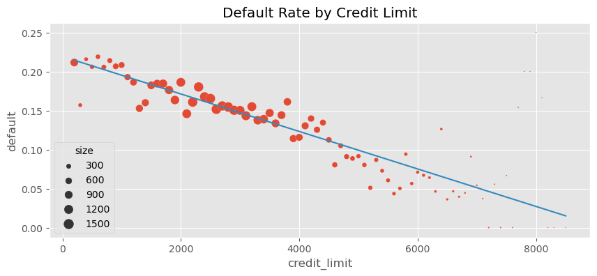

```python
plt_df = (risk_data
          .assign(size=1)
          .groupby("credit_limit")
          .agg({"default": "mean", "size":sum})
          .reset_index()
          .assign(prediction = lambda d: model.predict(d)))

plt.figure(figsize=(10,4))

sns.scatterplot(data=plt_df,
                x="credit_limit",
                y="default",
                size="size",
                sizes=(1,100))

plt.plot(plt_df["credit_limit"], plt_df["prediction"], color="C1")
plt.title("Default Rate by Credit Limit")
plt.show()
```

- 교란 편향을 보정하려면, 이론적으로는

  **모든 교란 요인에 따라 1) 데이터를 나누고, 2) 나눈 각 그룹 내에서 채무불이행률을 신용 한도에 회귀하고, 3) 기울기 매개변수 추출을 통해 결과의 평균을 계산**

  $\rightarrow$ **하지만 독립변수는 연속형**

  $\rightarrow$ **회귀분석을 통해 교란 요인을 직접 보정하는 대신, OLS로 추정할 모델에 교란 요인을 추가**

$$Default_i = \beta_0 + \beta_i line_i + \theta X_i + e_i$$

- **$X$는 교란 요인의 벡터, $\theta$는 해당 교란 요인과 관련된 매개변수의 벡터**
  - $\theta$의 매개변수는 특별하지 않고 $\beta_1$과 똑같이 작동
  - $\theta$의 인과관계 해석에는 신경 쓰지 않아도 되며, 이는 **장애 모수** (Nuisance Parameter)

$$Default_i = \beta_0 + \beta_i line_i + \theta_1 wage_i + \theta_2 creditScore1_i + \theta_3 creditScore2_i + e_i$$

- $\beta_1$은 신용 한도에 대한 채무불이행률 기댓값의 편도함수

  $\rightarrow$ **모델의 다른 모든 변수가 고정된 상태에서 신용 한도를 조금 늘렸을 때 채무 불이행률이 얼마나 변할지에 대한 기댓값**

  $\rightarrow$ **회귀분석의 교란 요인 보정 원리 : 처치와 결과 사이의 관계를 추정하는 동안 교란 요인을 고정**

$$\frac{\delta}{\delta t}E[y|t, X]$$

```python
formula = 'default ~ credit_limit + wage+credit_score1+credit_score2'
model = smf.ols(formula, data=risk_data).fit()
model.summary().tables[1]
```

|  | coef | std err | t | P>\|t\| | [0.025 | 0.975] |
| --- | --- | --- | --- | --- | --- | --- |
| Intercept | 0.4037 | 0.009 | 46.939 | 0.000 | 0.387 | 0.421 |
| credit_limit | 3.063e-06 | 1.54e-06 | 1.987 | 0.047 | 4.16e-08 | 6.08e-06 |
| wage | -8.822e-05 | 6.07e-06 | -14.541 | 0.000 | -0.000 | -7.63e-05 |
| credit_score1 | -4.175e-05 | 1.83e-05 | -2.278 | 0.023 | -7.77e-05 | -5.82e-06 |
| credit_score2 | -0.0003 | 1.52e-05 | -20.055 | 0.000 | -0.000 | -0.000 |

## 04.02 회귀분석 이론

- **$\beta *$ : 매개변수 벡터**

$$\beta^* = \argmin_\beta E [(Y_i - X^{'}_i \beta)^2]$$

- 선형회귀분석은 MSE를 최소화 하는 매개변수를 탐색

  이를 미분하고 그 결과를 0으로 두면, 이 문제에 대한 선형 해

$$\beta^* = E[X^{'} X]^{-1} E[X^{'}Y]$$

- 표본을 통하여 다음과 같이 회귀계수를 추정

$$\hat{\beta} = (X^{'}X)^{-1} X^{'}Y$$

```python
X_cols = ["credit_limit", "wage", "credit_score1", "credit_score2"]
X = risk_data[X_cols].assign(intercep=1)
y = risk_data["default"]
```

```python
def regress(y, X):
    return np.linalg.inv(X.T.dot(X)).dot(X.T.dot(y))

beta = regress(y, X)
beta
```

```
array([ 3.06252773e-06, -8.82159125e-05, -4.17472814e-05, -3.03928359e-04,
        4.03661277e-01])
```

### 01. 단순선형회귀

- 인과추론에서는 변수 $T$가 결과 $Y$에 미치는 인과효과를 추정하려는 경우가 빈번
- 단일 설명변수 $T$를 사용할 때 관련된 매개변수

$$\hat{\tau} = \frac{Cov(Y_i, T_i)}{Var(T_i)} = \frac{E[(T_i - \bar{T}) (Y_i - \bar{Y})]}{E[(T_i - \bar{T})^2]}$$

- $T$가 무작위로 배정된 경우, $\beta_1$는 ATE
- 회귀분석은 처치와 결과가 어떻게 함께 움직이는지를 파악하고, 이를 처치 대상에 따라 조정

### 02. 다중선형회귀

- 설명변수가 두 개 이상일 떄
- 다른 변수는 보조적인 변수일 뿐이고, 관심 있는 진짜 부분은 $T$와 관련된 매개변수 $\tau$를 추정 하는것

$$Y-i = \beta_0 + \tau T_i + \beta_1 X_{1i} + \dots + \beta_k X_{ki} + u_i$$

- $\tau$는 다음 공식으로 추정

$$\hat{\tau} = \frac{Cov(Y_i, \tilde{T_i})}{Var(\tilde{T_i})}$$

- $\tilde{T_i}$는 $T_i$를 모든 공변량 $X_{1i} + \dots + X_{ki}$에 대해 회귀한 잔차
- **다중회귀분석의 회귀계수는, 다른 변수들을 이미 통제한 상태에서 $X_i$와 $Y$사이의 1:1관계 (이변량 계수)**

## 04.03 프리슈-워-로벨 정리와 직교화 (FWL)

- 가장 먼저 사용할 수 있는 편향 제거 기법 (Debiasing)
- **비실험 (Nonexperimental) 데이터를 처치가 무작위 배정된 것 처럼 보이게 함**
- **FWL 정리에 따르면, 다중선형회귀분석은 한 번에 추정하거나 세 단계로 나누어 추정 가능**
1. **편향 제거 단계** : 처치 $T$를 교란 요인 $X$에 회귀하여 처치 잔차 $\tilde{T} = T- \hat{T}$를 계산
2. **노이즈 제거 단게** : 결과 $Y$를 교란 요인 $X$에 대해 회귀하여 결과 잔차 $\tilde{Y} = Y- \hat{Y}$ 계산
3. **결과 모델 단계** : 결과 잔차 $\tilde{Y}$를 처치 잔차 $\tilde{T}$에 대해 회귀하여 $T$가 $Y$에 미치는 인과효과 추정값 계산

$\rightarrow$ **편향 제거 모델에 사용된 교란 요인들을 통제하면서 처치가 결과에 미치는 영향을 파악**

### 01. 편향 제거 단계

- 교란편향의 영향으로 신용 한도에 따라 채무불이행이 감소하는 추세

  (은행은 위험이 적은 고객에게 더 높은 한도를 주는 경향)

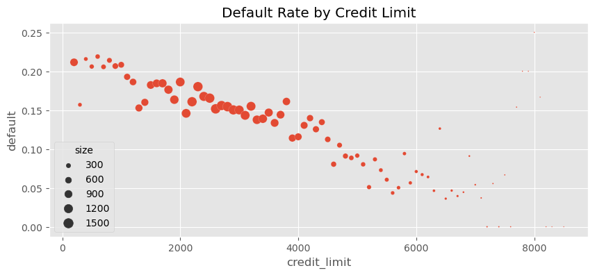

```python
plt_df = (risk_data
          .assign(size=1)
          .groupby("credit_limit")
          .agg({"default": "mean", "size":sum})
          .reset_index())

plt.figure(figsize=(10,4))
sns.scatterplot(data=plt_df,
                x="credit_limit",
                y="default",
                size="size",
                sizes=(1,100))


plt.title("Default Rate by Credit Limit")
plt.show()
```

- **FWL 정리에 따르면, 교란 요인으로부터 처치인 신용 한도를 예측하는 회귀 모델을 적합시켜, 데이터의 편향을 제거 가능**

  $\rightarrow$ **처치 (신용 한도) 대한 잔차를 계산 ($\tilde{line}_i = line_i - \hat{line}_i$)**

  $\rightarrow$ **이 잔차는 편향 제거 모델에 사용되는 변수와는 상관관계가 없는 버전의 처치 (예측값을 생성한 변수와 직교하기 때문)**

  $\rightarrow$ 0을 중심으로한 $\tilde{line}_i$이 생성. (필요에 따라 평균 처치인 $\bar{line}_i$을 다시 추가)
- 처치를 교란 요인에 회귀

```python
debiasing_model = smf.ols(
    'credit_limit ~ wage + credit_score1  + credit_score2', data=risk_data
).fit()
```

- 반응 변수를 처치 잔차에 회귀

  $\rightarrow$ **처치 잔차의 회귀계수 $\beta_1$은, 처치와 교란 요인을 모두 포함한 완전모델의 처치 회귀계수와 동일**

  $\rightarrow$ **처치가 결과에 미치는 인과적 영향에 대해, 편향되지 않은 추정값 (Unbiased Estimator)을 얻을 수 있음**

```python
risk_data_deb = risk_data.assign(
    credit_limit_res=(debiasing_model.resid)
)

model_w_deb_data = smf.ols('default ~ credit_limit_res', data=risk_data_deb).fit()
model_w_deb_data.summary().tables[1]
```

|  | coef | std err | t | P>\|t\| | [0.025 | 0.975] |
| --- | --- | --- | --- | --- | --- | --- |
| Intercept | 0.1508 | 0.002 | 94.230 | 0.000 | 0.148 | 0.154 |
| credit_limit_res | 3.063e-06 | 1.56e-06 | 1.957 | 0.050 | -4.29e-09 | 6.13e-06 |

- **편향이 제거된 처치와 결과의 산점도 : 편향되었을 때와는 달리, 두 변수 사이의 관계가 하향선이 아님**

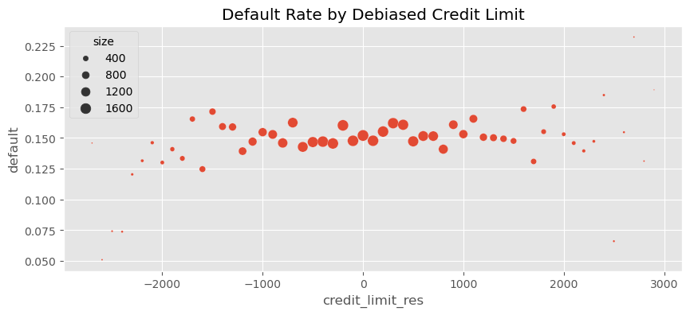

```python
plt_df = (risk_data_deb
          .assign(size=1)
          .assign(credit_limit_res = lambda d: d["credit_limit_res"].round(-2))
          .groupby("credit_limit_res")
          .agg({"default": "mean", "size":sum})
          .query("size>30")
          .reset_index())

plt.figure(figsize=(10,4))
sns.scatterplot(data=plt_df,
                x="credit_limit_res",
                y="default",
                size="size",
                sizes=(1,100))

plt.title("Default Rate by Debiased Credit Limit")
plt.show()
```

### 02. 잡음 제거 단계

- 잡음 제거단계는 필수는 아니지만, 인과효과 추정의 정확함을 위해 중요
- **잡음을 제거한다고 해서 처치효과의 추정값이 바뀌지 않지만 분산을 줄일 수 있음**
- 결과를 공변량에 대해 회귀하여 결과에 대한 잔차를 얻음

  $\rightarrow$ **결과에 공변량이 설명하는 부분을 분리/제거하고, 공변량과 독립된 순수한 결과의 변동만 남김**

$$\tilde{default}_i = default_i = \hat{default}_i$$

```python
denoising_model = smf.ols(
    'default ~ wage + credit_score1  + credit_score2', data=risk_data_deb
).fit()
```

```python
risk_data_denoise = risk_data_deb.assign(default_res=denoising_model.resid)
```

### 03. 회귀 추정량의 표준오차

- 추정한 회귀계수의 표준 오차
  - $\hat{\epsilon}$ : 회귀모델의 잔차
  - $DF$ : 모델의 자유도 (모델이 추정하는 매개변수의 수)

$$SE(\hat{\beta}) = \frac{\sigma{\hat{\epsilon}}}{\sigma(\tilde{T}) \sqrt{n-DF}}$$

- 결과를 잘 예측할수록 잔차 감소 $\rightarrow$ 추정값의 분산이 감소
- 처치가 결과를 잘 설명할수록, 회귀계수 추정값의 표준오차도 감소

  $\rightarrow$ **오차는 잔차화된 처치의 분산에 반비례**

### 04. 최종 결과 모델

- FWL의 마지막 단계인 결과모델에서는 두 잔차 $\tilde{Y}$와 $\tilde{T}$를 이용하여, 단순히 $\tilde{Y}$를 $\tilde{T}$에 회귀

```python
model_w_orthogonal = smf.ols('default_res ~ credit_limit_res', data=risk_data_denoise).fit()

model_w_orthogonal.summary().tables[1]
```

|  | coef | std err | t | P>\|t\| | [0.025 | 0.975] |
| --- | --- | --- | --- | --- | --- | --- |
| Intercept | 6.484e-16 | 0.002 | 4.11e-13 | 1.000 | -0.003 | 0.003 |
| credit_limit_res | 3.063e-06 | 1.54e-06 | 1.987 | 0.047 | 4.17e-08 | 6.08e-06 |

- **편향 제거 단계에서 얻은 회귀계수 추정값은, 완전 모델의 회귀계수와 동일**
  - 표준오차와 $p$값도 완전모델과 동일
- 편향 제거된 처치와, 잡음이 제거된 결과 간의 관계

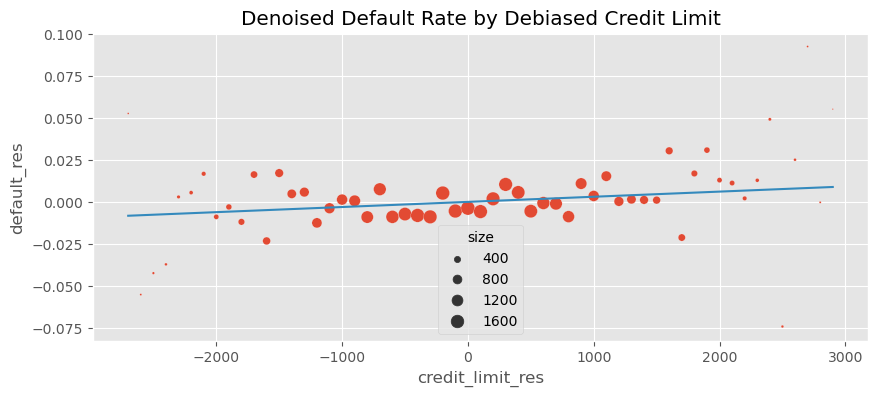

```python
plt_df = (risk_data_denoise
          .assign(size=1)
          .assign(credit_limit_res = lambda d: d["credit_limit_res"].round(-2))
          .groupby("credit_limit_res")
          .agg({"default_res": "mean", "size":sum})
          .query("size>30")
          .reset_index()
          .assign(prediction = lambda d: model_w_orthogonal.predict(d)))

plt.figure(figsize=(10,4))
sns.scatterplot(data=plt_df,
                x="credit_limit_res",
                y="default_res",
                size="size",
                sizes=(1,100))

plt.plot(plt_df["credit_limit_res"], plt_df["prediction"], c="C1")

plt.title("Denoised Default Rate by Debiased Credit Limit")
plt.show()
```

### 05. FWL 정리 요약

- 처치 $T$와 결과 $Y$ 사이의 관계를 추정하고 싶지만, 교란 요인 $X$가 존재하는 상황

#### 편향 제거

- 선형회귀분석을 이용하여 $E[T|X]$를 추정

  $\rightarrow$ 편향이 제거된 버전의 처치 $T-[E|T|X]$를 계산

  $\rightarrow$ 편향이 제거된 처치를 사용하면 탐색하려는 양의 관계를 확인 가능

#### 잡음 제거

- 회귀모델을 사용하여 $E[Y|X]$를 추정하고, 잡음 제거된 결과 $Y-E[Y|X]$를 도출

  $\rightarrow$ 잡음 제거된 결과를, $X$에 의해 설명된 모든 분산을 고려한 후의 결과로 간주

  $\rightarrow$ $X$가 $Y$의 분산을 많이 설명하면, 잡음 제거된 결과에는 잡음이 적어지므로, 실제로 관심있는 $T$와 $Y$ 사이의 관계를 쉽게 파악

#### 최종 모델 적합

- 편향과 잡음을 제거한 후 $T$와 $Y$ 사이의 관계 파악

### 편향 제거와 절편

- 인과추론에서는 절편보다는 주로 회귀선의 기울기에 관심.

  해당 기울기가 연속형 처치의 효과 $\frac{\delta}{\delta t} E[y|t]$에 대한 선형 근삿값이기 때문

## 04.04. 결과 모델으로서의 회귀분석

- 회귀분석은 잠재적 결과를 대체하는 방법으로도 접근 가능
- 처치가 0 또는 1의 이진값으로 주어진 경우, 대조군 $T=0$에서 $X$에 대한 $Y$의 회귀분석이 $E[Y_0|X]$를 잘 근사한다면

  해당 모델을 이용해 $Y_0$를 대체하고 ATT를 추정 가능
  - $N_\mathbb{1}$ : 실험군 대상자의 수
  - $\mathbb{I}(.)$ : 안에 있는 인수가 참이면 1을 반환하고, 그렇지 않으면 0을 반환하는 지시함수

$$ATT = \frac{1}{N_1}\sum \mathbb{I} (T_i=1)(Y_i -\hat{\mu}(X_i))$$

- 실험군 $T=1$에서 $X$에 대한 $Y$의 회귀분석이 $E[Y_1|X]$를 잘 모델링할 수 있다면, 이를 이용하여 대조군에서의 평균 효과를 추정

  이 추정량은 모든 실험 대상의 두 가지 잠재격 결과를 모두 대체하며, **$Y$를 $X$와 $T$ 모두에 회귀하고, $T$에 대한 매개변수 추정값을 얻는 것과 동일**

$$ATE = \frac{1}{N}\sum(\hat{\mu}_1(X_i) - \hat{\mu}_0 (X_i))$$

- 또한 누락된 잠재적 결과를 대체할 수도 있음

$$ATE = \frac{1}{N}\sum (\mathbb{I}(T_i=1)[Y_i - \hat{\mu_0}(X_i)] + \mathbb{I}(T_i=0)[\hat{\mu}(X_i)-Y_i])$$

- **회귀분석은 전체 처치 반응 함수를 대체하는 것으로 이해할 수 있으며, 여기에는 잠재적 결과 $Y(t)$를 선처럼 대체하는 것이 포함**
- $E[T|X]$를 정확하게 추정하여 직교화할 수 있거나, 잠재적 결과 $E[Y_1|X]$를 정확하게 추정할 수 있다는 사실은,

  회귀분석이 이중 강건하다는 특성을 나타냄

## 04.05 양수성과 외삽

- **회귀분석은 잠재적 결과를 모수적으로 모델링하므로, 데이터의 처치 범위 이외에 대해서도 외삽이 가능**

### 양수성 (Positivity)

- **모든 공변량 $X$ 값에서 $T=1$(실험군)과 $T=0$(대조군) 둘 다 있어야 함**

  **즉, 어떤 $X$구간에서는 항상 실험군만 있거나, 또는 항상 대조군만 있으면 안됨**

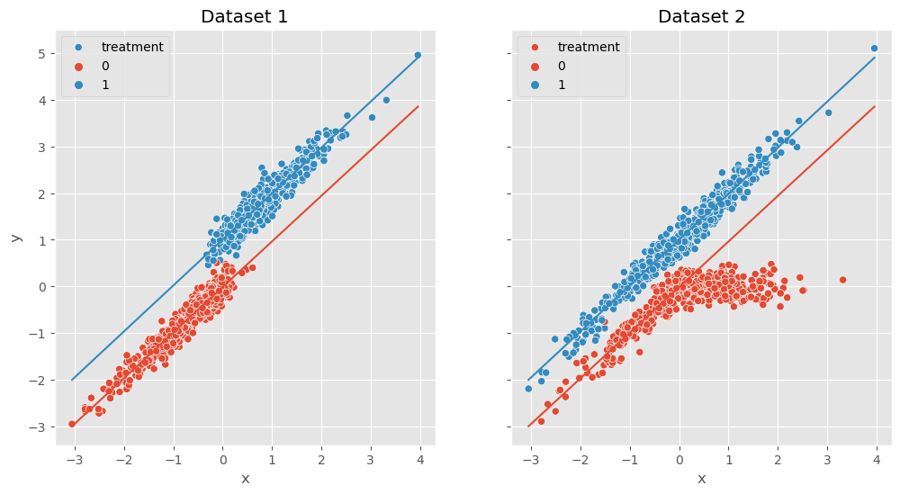

```python
np.random.seed(1)

n = 1000
x = np.random.normal(0, 1, n)
t = np.random.normal(x, 0.2, n) > 0

y0 = x
y1 = 1 + x

y = np.random.normal((1-t)*y0 + t*y1, 0.2)

df_no_pos = pd.DataFrame(dict(x=x,t=t.astype(int),y=y))

fig, (ax1, ax2) = plt.subplots(1, 2, figsize=(12, 6), sharey=True)

sns.scatterplot(data=df_no_pos, x="x", y="y", hue="t", ax=ax1, label="treatment")

m0 = smf.ols("y~x", data=df_no_pos.query(f"t==0")).fit()
m1 = smf.ols("y~x", data=df_no_pos.query(f"t==1")).fit()

sns.lineplot(data=df_no_pos.assign(pred=m0.predict(df_no_pos)), x="x", y="pred", color=f"C0", ax=ax1)
sns.lineplot(data=df_no_pos.assign(pred=m1.predict(df_no_pos)), x="x", y="pred", color=f"C1", ax=ax1);
ax1.set_title("Dataset 1")

np.random.seed(1)

n = 1000
x = np.random.normal(0, 1, n)
t = np.random.binomial(1, 0.5, size=n)

y0 = x * (x<0) + (x>0)*0
y1 = 1 + x

y = np.random.normal((1-t)*y0 + t*y1, 0.2)

df_pos = pd.DataFrame(dict(x=x,t=t.astype(int),y=y))

sns.scatterplot(data=df_pos, x="x", hue="t", y="y", ax=ax2, label="treatment")

sns.lineplot(data=df_no_pos.assign(pred=m0.predict(df_pos)), x="x", y="pred", color=f"C0", ax=ax2)
sns.lineplot(data=df_no_pos.assign(pred=m1.predict(df_pos)), x="x", y="pred", color=f"C1", ax=ax2)
ax2.set_title("Dataset 2")

plt.show()
```

## 04.06 선형회귀에서의 비선형성

- **신용 한도가 신용카드 소비에 미치는 인과 효과 추정**
  - 은행에서 신용한도를 결정할 때, 유일하게 임금 정보만을 사용하는 상황일 때 $\rightarrow$ 임금은 교란 요인

  $\rightarrow$ 신용한도가 소비에 미치는 영향을 파악하기 위해 임금을 통제

```python
spend_data = pd.read_csv("./data/spend_data.csv")
```

```python
g_risk = gr.Digraph(graph_attr={"rankdir":"LR"})

g_risk.edge("임금", "신용 한도")
g_risk.edge("임금", "소비")
g_risk.edge("신용 한도", "소비")

g_risk
```

[figure not shown]

- 여러 임금 수준에서 신용 한도별 소비 그래프를 살펴보면, 두 변수 사이의 관계는 선형적이지 않음
  - 오히려 처치 반응 곡선에는 오목성 (Convacity)가 존재 (신용한도가 높을수록 곡선의 기울기가 낮아짐)

  $\rightarrow$ 신용한도가 증가함에 따라, 한도가 소비에 미치는 효과는 점진적으로 감소

  $\rightarrow$ 즉, 한도를 2,000에서 3,000으로 늘렸을 때보다 1,000에서 2,000으로 늘렸을 떄 소비가 더 많이 증가

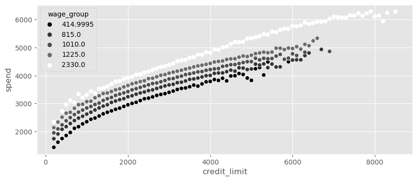

```python
plt_df = (spend_data
          .assign(wage_group = lambda d: pd.IntervalIndex(pd.qcut(d["wage"], 5)).mid)
          .groupby(["wage_group", "credit_limit"])
          [["spend"]]
          .mean()
          .reset_index())

plt.figure(figsize=(10,4))
sns.scatterplot(data=plt_df,
                x="credit_limit",
                y="spend",
                hue="wage_group",
                palette="gray")

plt.show()
```

### 01. 처치 선형화

- **처치를 결과와 선형 관계로 변환** (로그함수, 제곱근 함수 등)

$$sepnd_i = \beta_0 + \beta_1 \sqrt{line_i} + \epsilon_i$$

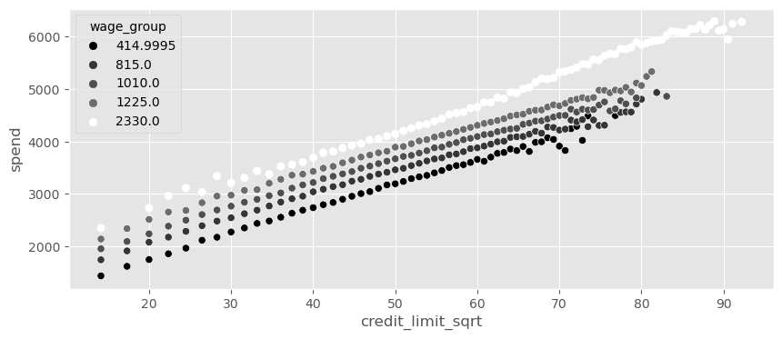

```python
plt_df = (spend_data
          .assign(credit_limit_sqrt = np.sqrt(spend_data["credit_limit"]))
          .assign(wage_group = pd.IntervalIndex(pd.qcut(spend_data["wage"], 5)).mid)
          .groupby(["wage_group", "credit_limit_sqrt"])
          [["spend"]]
          .mean()
          .reset_index())

plt.figure(figsize=(10,4))
sns.scatterplot(data=plt_df,
                x="credit_limit_sqrt",
                y="spend",
                palette="gray",
                hue="wage_group")

plt.show()
```

```python
model_spend = smf.ols(
    'spend ~ np.sqrt(credit_limit)',data=spend_data).fit()

model_spend.summary().tables[1]
```

|  | coef | std err | t | P>\|t\| | [0.025 | 0.975] |
| --- | --- | --- | --- | --- | --- | --- |
| Intercept | 493.0044 | 6.501 | 75.832 | 0.000 | 480.262 | 505.747 |
| np.sqrt(credit_limit) | 63.2525 | 0.122 | 519.268 | 0.000 | 63.014 | 63.491 |

- 임금이 신용 한도와 소비 사에에서 교란으로 작용하고 있으므로, 모델의 예측값의 기울기가 상향 편향되어 있음
  - 임금이 높아지면 소비와 신용 한도 모두 증가하기 때문

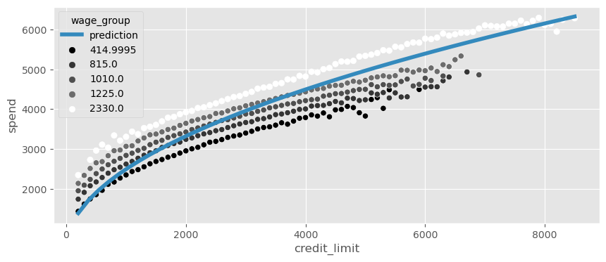

```python
plt_df = (spend_data
          .assign(wage_group = lambda d: pd.IntervalIndex(pd.qcut(d["wage"], 5)).mid)
          .groupby(["wage_group", "credit_limit"])
          [["spend"]]
          .mean()
          .reset_index()
         )

x = np.linspace(plt_df["credit_limit"].min(), plt_df["credit_limit"].max())

plt.figure(figsize=(10,4))
plt.plot(x, model_spend.params[0] + model_spend.params[1]*np.sqrt(x), color="C1", label="prediction", lw=4)
plt.legend()
sns.scatterplot(data=plt_df,
                x="credit_limit",
                y="spend",
                palette="gray",
                hue="wage_group")

plt.show()
```

$$spend_i = \beta_0 + \beta_1 \sqrt{line_i} + \beta_2 wage_i + \epsilon_i$$

```python
model_spend = smf.ols('spend ~ np.sqrt(credit_limit)+wage', data=spend_data).fit()

model_spend.summary().tables[1]
```

|  | coef | std err | t | P>\|t\| | [0.025 | 0.975] |
| --- | --- | --- | --- | --- | --- | --- |
| Intercept | 383.5002 | 2.746 | 139.662 | 0.000 | 378.118 | 388.882 |
| np.sqrt(credit_limit) | 43.8504 | 0.065 | 672.633 | 0.000 | 43.723 | 43.978 |
| wage | 1.0459 | 0.002 | 481.875 | 0.000 | 1.042 | 1.050 |

### 02. 비선형 FWL과 편향 제거

- 선형회귀분석을 이용해 비선형 모델을 추정하는 과정
1. **처치 선형화 단계** : $T$와 $Y$의 관계를 선형화 하는 함수 $F$를 탐색
2. **편향 제거 단계** : $F(T)$를 교란 요인 $X$에 회귀하고, 처치 잔차 $\tilde{F(T)} = F(T)- \hat{F(T)}$를 계산
3. **잡음 제거 단계** : 결과 $Y$를 교란 요인 $X$에 회귀하고, 결과 잔차 $\tilde{Y} = Y - \hat{Y}$를 계산
4. **결과 모델 단계** : 결과 잔차 $\tilde{Y}$를 처치 잔차 $\tilde{F(t)}$에 회귀하여, $F(T)$가 $Y$에 미치는 인과효과의 추정값을 계산
- 처치 선형화 & 편향 제거
  - $F$ : 제곱근 함수

```python
debias_spend_model = smf.ols(f'np.sqrt(credit_limit) ~ wage', data=spend_data).fit()
```

- 잡음 제거

```python
denoise_spend_model = smf.ols(f'spend ~ wage', data=spend_data).fit()
```

- 결과 모델

```python
credit_limit_sqrt_deb = (debias_spend_model.resid)
spend_den = denoise_spend_model.resid

spend_data_deb = (spend_data.assign(
    credit_limit_sqrt_deb = credit_limit_sqrt_deb,
    spend_den = spend_den))

final_model = smf.ols(f'spend_den ~ credit_limit_sqrt_deb', data=spend_data_deb).fit()
final_model.summary().tables[1]
```

|  | coef | std err | t | P>\|t\| | [0.025 | 0.975] |
| --- | --- | --- | --- | --- | --- | --- |
| Intercept | -7.105e-13 | 0.704 | -1.01e-12 | 1.000 | -1.379 | 1.379 |
| credit_limit_sqrt_deb | 43.8504 | 0.065 | 672.640 | 0.000 | 43.723 | 43.978 |

## 04.07 더미변수

### 01. 조건부 무작위 실험

- 무작위 통제 실험에는 큰 비용이 수반

  $\rightarrow$ **계층화 (Stratified) 또는 조건부 (Conditional) 무작위 실험**

  $\rightarrow$ **공변량에 따라 서로 다른 분포에서 표본을 뽑아 여러 국소 실험 진행**
  - 예) `credit_score1`변수가 고객 위험도의 대리변수일 때, 비슷한 고객들을 묶어 고객 그룹을 생성
    - `credit_score1`이 낮은 고위험 그룹은, 평균이 낮은 분포에서 신용한도를 추출하여 무작위로 배정
    - `credit_score1`이 높은 저위험 고객은, 평균이 높은 분포에서 신용한도를 추출하여 무작위로 배정
- 신용 한도의 히스토그램을 `credit_score1_buckets`별로 표시
  - 점수가 높은 고객 (저위험 고객) 그룹은 히스토그램이 왼쪽으로 꼬리가 길며, 신용 한도가 더 높음
  - 점수가 낮은 고객 (고위험 고객) 그룹은 히스토그램이 오른쪽으로 꼬리가 길며, 신용 한도가 더 낮음

```python
risk_data_rnd = pd.read_csv("./data/risk_data_rnd.csv")
```

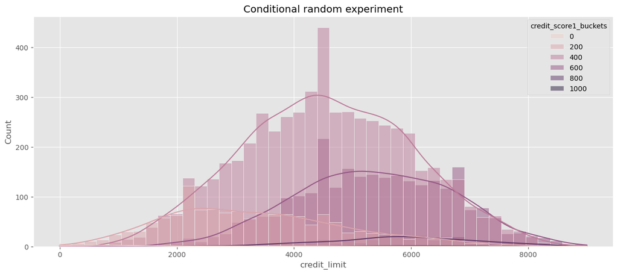

```python
plt.figure(figsize=(15,6))
sns.histplot(data=risk_data_rnd,
             x="credit_limit",
             hue="credit_score1_buckets",
             kde=True);
plt.title("Conditional random experiment")
plt.show()
```

- **조건부 무작위 실험은 비용이 더 저렴하지만 복잡성이 높음**

  $\rightarrow$ **어떤 이유로든 조건부 무작위 실험을 선택한다면, 가능한 완전 무작위 실험에 가깝게 설계해야 함**
  - **1. 그룹 수가 적을수록 조건부 무작위 실험을 진행하는 것이 쉬움**
    - 처치 분포가 서로 다른 여러 그룹을 결합하면 복잡해지므로, 적은 수의 그룹을 유지하는 것이 좋음
  - **2. 그룹 간 처치 분포가 많이 중첩될수록 분석이 용이 (양수성 가정)**
    - 고위험 그룹이 높은 신용 한도를 받을 확률이 0인 경우, 고위험 그룹이 높은 신용 한도를 받게될지 알기 위한 외삽은 리스크가 증가

### 02. 더미변수

- 조건부 무작위 실험의 장점은 설정한 범주형 변수에 따라 신용 한도가 무작위로 배정됨을 알기 때문에, 조건부 독립 가정에 훨씬 더 설득력이 생김
- **하지만 실험군에 대한 결과만으로 단순 회귀분석을 하면 편향된 추정값을 얻게 될 수 있음**
  - 예) 교란 요인인 임금을 포함하지 않고 모델 추정 시, 신용 한도가 높을수록 채무불이행 위험을 낮춘다는 결과가 산출

  $\rightarrow$ 실험이 설계된 방식으로 인해, 위험도가 낮은 고객 (`credit_score1`이 높은 고객)이 평균적으로 더 높은 한도를 받았기 때문

$$default_i = \beta_0 + \beta_1 lines_i + e_i$$

```python
model = smf.ols("default ~ credit_limit", data=risk_data_rnd).fit()
model.summary().tables[1]
```

|  | coef | std err | t | P>\|t\| | [0.025 | 0.975] |
| --- | --- | --- | --- | --- | --- | --- |
| Intercept | 0.1369 | 0.009 | 15.081 | 0.000 | 0.119 | 0.155 |
| credit_limit | -9.344e-06 | 1.85e-06 | -5.048 | 0.000 | -1.3e-05 | -5.72e-06 |

- **이를 보정하기 위해 처치가 무작위로 배정된 그룹 정보를 포함해야 함 (`credit_score1_buckets`)**

  $\rightarrow$ **범주형 변수를 통제하는 방법은 더미변수를 만드는 것 (원-핫 인코딩)**

```python
pd.set_option('display.max_columns', 9)
```

```python
risk_data_rnd[['credit_score1_buckets']].drop_duplicates()
```

|  | credit_score1_buckets |
| --- | --- |
| 0 | 400 |
| 1 | 200 |
| 3 | 600 |
| 25 | 800 |
| 332 | 0 |
| 706 | 1000 |

```python
risk_data_dummies = risk_data_rnd.join(pd.get_dummies(
        risk_data_rnd["credit_score1_buckets"],
        prefix="sb",
        drop_first=True
    )
)

risk_data_dummies.head()
```

|  | wage | educ | exper | married | ... | sb_400 | sb_600 | sb_800 | sb_1000 |
| --- | --- | --- | --- | --- | --- | --- | --- | --- | --- |
| 0 | 890.0 | 11 | 16 | 1 | ... | 1 | 0 | 0 | 0 |
| 1 | 670.0 | 11 | 7 | 1 | ... | 0 | 0 | 0 | 0 |
| 2 | 1220.0 | 14 | 9 | 1 | ... | 1 | 0 | 0 | 0 |
| 3 | 1210.0 | 15 | 8 | 1 | ... | 0 | 1 | 0 | 0 |
| 4 | 900.0 | 16 | 1 | 1 | ... | 0 | 0 | 0 | 0 |

5 rows × 14 columns

- 더미변수를 추가한 회귀 모델
  - 신용한도가 높을수록 채무불이행 위험이 높아진다는 결과

$$default_i = \beta_0 + \beta_1 lines_i + \theta G_i + e_i$$

```python
model = smf.ols("default ~ credit_limit + C(credit_score1_buckets)", data=risk_data_rnd).fit()

model.summary().tables[1]
```

|  | coef | std err | t | P>\|t\| | [0.025 | 0.975] |
| --- | --- | --- | --- | --- | --- | --- |
| Intercept | 0.2253 | 0.056 | 4.000 | 0.000 | 0.115 | 0.336 |
| C(credit_score1_buckets)[T.200] | -0.0559 | 0.057 | -0.981 | 0.327 | -0.168 | 0.056 |
| C(credit_score1_buckets)[T.400] | -0.1442 | 0.057 | -2.538 | 0.011 | -0.256 | -0.033 |
| C(credit_score1_buckets)[T.600] | -0.2148 | 0.057 | -3.756 | 0.000 | -0.327 | -0.103 |
| C(credit_score1_buckets)[T.800] | -0.2489 | 0.060 | -4.181 | 0.000 | -0.366 | -0.132 |
| C(credit_score1_buckets)[T.1000] | -0.2541 | 0.094 | -2.715 | 0.007 | -0.438 | -0.071 |
| credit_limit | 4.652e-06 | 2.02e-06 | 2.305 | 0.021 | 6.97e-07 | 8.61e-06 |

- 교란 요인을 통제하려고, 더미변수를 추가하면 그룹당 하나의 절편이 생기지만, 모든 그룹에 동일한 기울기가 적용

  $\rightarrow$ **해당 기울기는 각 그룹의 회귀에 대한 분산 가중평균**

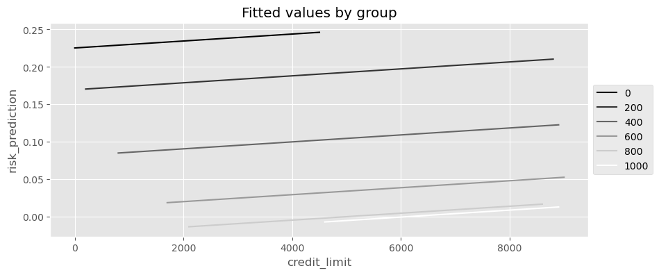

```python
plt_df = (risk_data_rnd
          .assign(risk_prediction = model.fittedvalues)
          .groupby(["credit_limit", "credit_score1_buckets"])
          ["risk_prediction"]
          .mean()
          .reset_index())

plt.figure(figsize=(10,4))
sns.lineplot(data=plt_df, x="credit_limit", y="risk_prediction", hue="credit_score1_buckets", palette = 'gray');
plt.title("Fitted values by group")
plt.legend(loc='center left', bbox_to_anchor=(1, 0.5))
plt.show()
```

### 03. 포화회귀모델

- **조건부 무작위 실험의 데이터를 `credit_score1_buckets`에 따라 나누고 그룹별로 효과 추정 (조건부 처치 효과)**

```python
def regress(df, t, y):
    return smf.ols(f"{y}~{t}", data=df).fit().params[t]
```

```python
effect_by_group = (risk_data_rnd
                   .groupby("credit_score1_buckets")
                   .apply(regress, y="default", t="credit_limit"))
effect_by_group
```

```
credit_score1_buckets
0      -0.000071
200     0.000007
400     0.000005
600     0.000003
800     0.000002
1000    0.000000
dtype: float64
```

- **각 그룹의 크기를 가중치로 삼아, 가중 평균 적용**

```python
group_size = risk_data_rnd.groupby("credit_score1_buckets").size()
ate = (effect_by_group * group_size).sum() / group_size.sum()
ate
```

```
4.490445628748721e-06
```

- **이를 회귀분석에 적용 $\rightarrow$ 포화모델 (Saturated Model)**

  $\rightarrow$ **더미변수와 처치에 대한 상호작용 항에서, 각 더미변수에 해당하는 그룹의 인과효과 추정**

```python
model = smf.ols("default ~ credit_limit * C(credit_score1_buckets)",
                data=risk_data_rnd).fit()
model.summary().tables[1]
```

|  | coef | std err | t | P>\|t\| | [0.025 | 0.975] |
| --- | --- | --- | --- | --- | --- | --- |
| Intercept | 0.3137 | 0.077 | 4.086 | 0.000 | 0.163 | 0.464 |
| C(credit_score1_buckets)[T.200] | -0.1521 | 0.079 | -1.926 | 0.054 | -0.307 | 0.003 |
| C(credit_score1_buckets)[T.400] | -0.2339 | 0.078 | -3.005 | 0.003 | -0.386 | -0.081 |
| C(credit_score1_buckets)[T.600] | -0.2957 | 0.080 | -3.690 | 0.000 | -0.453 | -0.139 |
| C(credit_score1_buckets)[T.800] | -0.3227 | 0.111 | -2.919 | 0.004 | -0.539 | -0.106 |
| C(credit_score1_buckets)[T.1000] | -0.3137 | 0.428 | -0.733 | 0.464 | -1.153 | 0.525 |
| credit_limit | -7.072e-05 | 4.45e-05 | -1.588 | 0.112 | -0.000 | 1.66e-05 |
| credit_limit:C(credit_score1_buckets)[T.200] | 7.769e-05 | 4.48e-05 | 1.734 | 0.083 | -1.01e-05 | 0.000 |
| credit_limit:C(credit_score1_buckets)[T.400] | 7.565e-05 | 4.46e-05 | 1.696 | 0.090 | -1.18e-05 | 0.000 |
| credit_limit:C(credit_score1_buckets)[T.600] | 7.398e-05 | 4.47e-05 | 1.655 | 0.098 | -1.37e-05 | 0.000 |
| credit_limit:C(credit_score1_buckets)[T.800] | 7.286e-05 | 4.65e-05 | 1.567 | 0.117 | -1.83e-05 | 0.000 |
| credit_limit:C(credit_score1_buckets)[T.1000] | 7.072e-05 | 8.05e-05 | 0.878 | 0.380 | -8.71e-05 | 0.000 |

- 상호작용 매개변수는 첫 번재 그룹의 효과와 연관지어 해석해야 함

  $\rightarrow$ `credit_limit`과 관련된 매개변수와 상호작용 항을 더하면 회귀분석을 사용해 그룹별로 추정된 효과를 얻을 수 있음

```python
(model.params[model.params.index.str.contains("credit_limit:")]  + model.params["credit_limit"]).round(9)
```

```
credit_limit:C(credit_score1_buckets)[T.200]     0.000007
credit_limit:C(credit_score1_buckets)[T.400]     0.000005
credit_limit:C(credit_score1_buckets)[T.600]     0.000003
credit_limit:C(credit_score1_buckets)[T.800]     0.000002
credit_limit:C(credit_score1_buckets)[T.1000]    0.000000
dtype: float64
```

- 각 선은 절편뿐만 아니라 기울기도 다름
- 또한 포화모델에는 매개변수 (자유도가) 더 많으며, 이는 다른 모든 조건이 동일할 때 분산이 더 큼을 의미

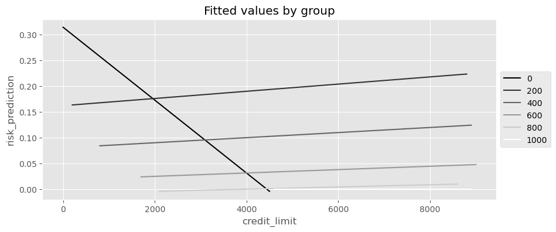

```python
plt_df = (risk_data_rnd
          .assign(risk_prediction = model.fittedvalues)
          .groupby(["credit_limit", "credit_score1_buckets"])
          ["risk_prediction"]
          .mean()
          .reset_index())

plt.figure(figsize=(10,4))
sns.lineplot(data=plt_df,
             x="credit_limit", y="risk_prediction", hue="credit_score1_buckets",  palette="gray");
plt.title("Fitted values by group")
plt.legend(loc='center left', bbox_to_anchor=(1, 0.5))
plt.show()
```

### 04. 분산의 가중평균과 회귀분석

- 상호작용항 없이 `default ~ credit_limit + C(credit_score1_buckets)`모델을 실행하면, 하나의 기울기 매개변수만 얻을 수 있음

  $\rightarrow$ **이 효과 추정값은 그룹별 효과를 추정하고 그룹 크기를 가중치로 사용하여 평균한 결과와 다름**

  $\rightarrow$ **즉, 회귀분석은 여러 그룹의 효과를 합친 것이지만, 표본 크기를 기준으로한 가중평균은 아니며, 처치의 분산에 비례하는 가중치를 사용**

#### 시뮬레이션

- 두 개의 다른 그룹
  - 첫 번째 그룹은 크기가 1,000이며 평균 처치효과가 1
  - 두 번째 그룹은 크기가 500이고 평균 처치효과가 2
  - 첫 번째와 두 번째 그룹의 처치효가의 표준편차는 각각 1과 2

```python
np.random.seed(123)

# std(t)=1
t1 = np.random.normal(0, 1, size=1000)
df1 = pd.DataFrame(dict(
    t=t1,
    y=1*t1, # ATE of 1
    g=1,
))

# std(t)=2
t2 = np.random.normal(0, 2, size=500)
df2 = pd.DataFrame(dict(
    t=t2,
    y=2*t2, # ATE of 2
    g=2,
))

df = pd.concat([df1, df2])
df.head()
```

|  | t | y | g |
| --- | --- | --- | --- |
| 0 | -1.085631 | -1.085631 | 1 |
| 1 | 0.997345 | 0.997345 | 1 |
| 2 | 0.282978 | 0.282978 | 1 |
| 3 | -1.506295 | -1.506295 | 1 |
| 4 | -0.578600 | -0.578600 | 1 |

- 그룹별 효과를 각각 추정하고, 그룹 크기를 가중치로 사용한 평균결과인 ATE는 1.33 = $\frac{(1 \times 1000 + 2\times 500)}{1500}$

```python
effect_by_group = df.groupby("g").apply(regress, y="y", t="t")
ate = (effect_by_group *
       df.groupby("g").size()).sum() / df.groupby("g").size().sum()
ate
```

```
1.3333333333333333
```

- **그룹을 통제하면서 $y$를 $t$에 회귀하면, 그룹 2의 표본이 그룹 1의 절반임에도 결합한 효과는 그룹 2의 효과에 더 가까움**

  $\rightarrow$ 회귀분석이 그룹 효과를 결합할 때 표본 크기를 가중치로 사용하지 않기 때문

  $\rightarrow$ **회귀분석은 각 그룹에서 처치의 분산에 비례하는 가중치를 사용**

  $\rightarrow$ **회귀분석은 처치 변동성이 큰 그룹을 선호**

```python
model = smf.ols("y ~ t + C(g)", data=df).fit()
model.params
```

```
Intercept    0.024758
C(g)[T.2]    0.019860
t            1.625775
dtype: float64
```

- **여러 그룹이 있고 각 그룹 내에서 처치가 무작위 배정된 경우, 조건부 원칙에 따르면 효과는 각 그룹내 효과의 가중평균**

$$ATE = E[(\frac{\delta}{\delta t} E[Y_i | T = t_i Group]) w(Group_i)]$$

- 회귀분석에서는 사용하는 방법에 따라 다른 가중치 적용 가능
  - $w(Group_i) \propto \sigma^2 (T)$
  - $w(Group_i) = N_{Group}$과 같이 표본 크기를 가중치로 사용하여 그룹 효과에 직접 가중치를 부여할 수 있음

### 05. 평균 제거와 고정효과

- **FWL 정리는 더미변수가 있는 상황에서 효과적**
  - 그룹이 많을 때, 각 그룹에 더미를 추가하는 것은 연산 과정이 복잡하며, 대부분이 0인 많은 열을 생성
- FWL 정리에서 편항 제거 단계는 공변량에서 처치를 예측하는 과정을 포함
  - 공변량이 더미변수

```python
model_deb = smf.ols("credit_limit ~ C(credit_score1_buckets)",
                    data=risk_data_rnd).fit()
model_deb.summary().tables[1]
```

|  | coef | std err | t | P>\|t\| | [0.025 | 0.975] |
| --- | --- | --- | --- | --- | --- | --- |
| Intercept | 1173.0769 | 278.994 | 4.205 | 0.000 | 626.193 | 1719.961 |
| C(credit_score1_buckets)[T.200] | 2195.4337 | 281.554 | 7.798 | 0.000 | 1643.530 | 2747.337 |
| C(credit_score1_buckets)[T.400] | 3402.3796 | 279.642 | 12.167 | 0.000 | 2854.224 | 3950.535 |
| C(credit_score1_buckets)[T.600] | 4191.3235 | 280.345 | 14.951 | 0.000 | 3641.790 | 4740.857 |
| C(credit_score1_buckets)[T.800] | 4639.5105 | 291.400 | 15.921 | 0.000 | 4068.309 | 5210.712 |
| C(credit_score1_buckets)[T.1000] | 5006.9231 | 461.255 | 10.855 | 0.000 | 4102.771 | 5911.076 |

- 더미변수는 기본적으로 그룹 평균과 비슷한 역할
  - 절편과 각 공변량의 회귀계수를 더한 것은 그룹별 평균과 동일

```python
risk_data_rnd.groupby("credit_score1_buckets")["credit_limit"].mean()
```

```
credit_score1_buckets
0       1173.076923
200     3368.510638
400     4575.456498
600     5364.400448
800     5812.587413
1000    6180.000000
Name: credit_limit, dtype: float64
```

#### 평균 제거

- **각 그룹별 평균 처치에서 해당 그룹의 평균을 빼서 잔차를 계산 $\rightarrow$ 평균 제거 (De-Meaning)**

  $\rightarrow$ 여기서 얻은 매개변수 추정값은 모델에 더미변수를 추가해서 얻은 값과 동일

  $\rightarrow$ **고정효과 (Fixed Effect) : 그룹 내에서 고정된 모든 것을 통제하여 얻은 모델**

```python
risk_data_fe = risk_data_rnd.assign(
    credit_limit_avg = lambda d: (d.groupby("credit_score1_buckets")["credit_limit"].transform("mean"))
)

risk_data_fe.head()
```

|  | wage | educ | exper | married | ... | credit_score1_buckets | credit_limit | default | credit_limit_avg |
| --- | --- | --- | --- | --- | --- | --- | --- | --- | --- |
| 0 | 890.0 | 11 | 16 | 1 | ... | 400 | 5400.0 | 0 | 4575.456498 |
| 1 | 670.0 | 11 | 7 | 1 | ... | 200 | 3800.0 | 0 | 3368.510638 |
| 2 | 1220.0 | 14 | 9 | 1 | ... | 400 | 5800.0 | 0 | 4575.456498 |
| 3 | 1210.0 | 15 | 8 | 1 | ... | 600 | 6500.0 | 0 | 5364.400448 |
| 4 | 900.0 | 16 | 1 | 1 | ... | 200 | 2100.0 | 0 | 3368.510638 |

5 rows × 10 columns

```python
model = smf.ols("default ~ I(credit_limit-credit_limit_avg)", data=risk_data_fe).fit()
model.summary().tables[1]
```

|  | coef | std err | t | P>\|t\| | [0.025 | 0.975] |
| --- | --- | --- | --- | --- | --- | --- |
| Intercept | 0.0935 | 0.003 | 32.121 | 0.000 | 0.088 | 0.099 |
| I(credit_limit - credit_limit_avg) | 4.652e-06 | 2.05e-06 | 2.273 | 0.023 | 6.4e-07 | 8.66e-06 |

#### 회귀 모델 안에 그룹별 평균 처치를 포함

- 회귀분석은 추가된 변수들로부터 처치를 잔차화

```python
model = smf.ols("default ~ credit_limit + credit_limit_avg", data=risk_data_fe).fit()
model.summary().tables[1]
```

|  | coef | std err | t | P>\|t\| | [0.025 | 0.975] |
| --- | --- | --- | --- | --- | --- | --- |
| Intercept | 0.4325 | 0.020 | 21.418 | 0.000 | 0.393 | 0.472 |
| credit_limit | 4.652e-06 | 2.02e-06 | 2.305 | 0.021 | 6.96e-07 | 8.61e-06 |
| credit_limit_avg | -7.763e-05 | 4.75e-06 | -16.334 | 0.000 | -8.69e-05 | -6.83e-05 |

#### 마케팅 믹스 모델링

- 광고가 매출에 미치는 영향을 측정
- **MMM은 마케팅 매출을 마케팅 전략 지표와 몇 가지 교란 요인에 회귀**

$$Sales_t = \delta_0 + \beta_1 TV_i + \beta_2 Social_i + \beta_3 Search_i + \delta_1 CompetitorSales_i + \delta_2 Month_i + \delta_3 Trend_i + e_i$$

- 효과가 좋은 달에 마케팅 예산을 늘렸을 수 있다는 점을 고려하여, 회귀 모델에 추가 통제변수를 포함해서 이 교란요인을 보정 가능
  - 예) 경쟁사의 매출, 각 월에 대한 더미 변수, 추세성 등

## 04.08. 누락 변수 편향

- 공통원인이 처치와 결과간 추정 관계를 편향시킬 수 있음 $\rightarrow$ 회귀 모델에 이러한 요인들을 포함해서 다루어야 함
- 예) 신용 한도가 채무불이행률에 미치는 영향을 추정
  - 임금이 유일한 교란요인이라는 가정

```python
g = gr.Digraph(graph_attr={"rankdir":"LR"})


g.edge("신용한도", "채무불이행")
g.edge("임금", "채무불이행"),
g.edge("임금", "신용한도")


g
```

[figure not shown]

- 이 경우 교란 요인을 포함하는 모델을 추정해야 함

$$default_i = \beta_0 + \beta_1 lines_i + \beta_2 wage_i + e_i$$

- **만약 교란 요인이 누락된 축소모델을 추정한다면 $\rightarrow$ 결과 추정값은 편향됨**

$$default_i = \beta_0 + \beta_1 lines_i$$

```python
short_model = smf.ols("default ~ credit_limit", data=risk_data).fit()
short_model.params["credit_limit"]
```

```
-2.401961992596886e-05
```

- **회귀분석을 통한 누락 변수 편향 (Ommitted Variable Bias, OVB)**
  - 결과에 대한 누락 교인의 회귀계수 $\beta^{'}_{omitted}$와, 처치에 대한 누락변수의 회귀계수 $\delta_{omitted}$를 곱한 값

$$\frac{Cov(T, Y)}{Var(T)}=\tau + \beta^{'}_{omitted} \delta_{omitted}$$

```python
long_model = smf.ols("default ~ credit_limit + wage", data=risk_data).fit()

omitted_model = smf.ols("wage ~ credit_limit", data=risk_data).fit()
```

```python
(long_model.params["credit_limit"] + long_model.params["wage"]*omitted_model.params["credit_limit"])
```

[output not shown]

## 4.9 중립 통제변수

- 회귀분석을 통한 교란 요인 보정하는 방법
  - 교란 요인 $X$를 보정하면서, 처치 $T$가 $Y$에 미치는 영향을 알고 싶다면 모델에 $X$를 포함하는 방법
  - 또 다른 방법으로는 $X$를 사용해 $T$를 예측한 후 잔차를 구하고, 이 잔차를 편향 제거된 (Debiased)처치로 사용하는 방법

  $\rightarrow$ **그렇다면 $X$에 어떤 변수를 포함해야 하는가?**
- 모든 변수들을 회귀모델에 포함하는 것은 바람직 하지 않음
  - 공통효과 (충돌부)나 매개자는 선택편향을 유발할 수 있기 때문
- 회귀분석에서 고려해야할 다른 유형의 통제변수 $\rightarrow$ 일부 변수가 무해해 보이지만, 실제로는 해로울 수 있는 통제 변수들

  $\rightarrow$ **회귀분석 추정에서 편향에 영향을 미치지 않는다는 중립적 변수**

  **분산에는 심각한 영향을 줄 수 있음**

  $\rightarrow$ **회귀 모델에 특정 변수를 포함할 때는 편향-분산 트레이드오프가 존재**
- 예) **`credit_score2`를 모델에 포함**

```python
g = gr.Digraph(graph_attr={"rankdir":"LR"})

g.edge("credit_score1_buckets", "Default"),
g.edge("credit_score1_buckets", "Lines"),
g.edge("credit_score2", "Default"),
g.edge("Lines", "Default")

g
```

[figure not shown]

- `credit_limit`의 매개변수 추정값이 조금 더 커졌지만, 표준오차가 감소

  $\rightarrow$ `credit_score2`가 결과 $Y$를 잘 예측하고 선형회귀의 잡음 제거 단계에 기여하기 떄문

  (FWL의 마지막 단계가 `credit_score2`를 포함하므로, $\tilde{Y}$의 분산이 감소하고 이를 $\tilde{T}$에 회귀하면 더 정확한 결과)

```python
formula = "default~credit_limit+C(credit_score1_buckets)+credit_score2"
model = smf.ols(formula, data=risk_data_rnd).fit()
model.summary().tables[1]
```

|  | coef | std err | t | P>\|t\| | [0.025 | 0.975] |
| --- | --- | --- | --- | --- | --- | --- |
| Intercept | 0.5576 | 0.055 | 10.132 | 0.000 | 0.450 | 0.665 |
| C(credit_score1_buckets)[T.200] | -0.0387 | 0.055 | -0.710 | 0.478 | -0.146 | 0.068 |
| C(credit_score1_buckets)[T.400] | -0.1032 | 0.054 | -1.898 | 0.058 | -0.210 | 0.003 |
| C(credit_score1_buckets)[T.600] | -0.1410 | 0.055 | -2.574 | 0.010 | -0.248 | -0.034 |
| C(credit_score1_buckets)[T.800] | -0.1161 | 0.057 | -2.031 | 0.042 | -0.228 | -0.004 |
| C(credit_score1_buckets)[T.1000] | -0.0430 | 0.090 | -0.479 | 0.632 | -0.219 | 0.133 |
| credit_limit | 4.928e-06 | 1.93e-06 | 2.551 | 0.011 | 1.14e-06 | 8.71e-06 |
| credit_score2 | -0.0007 | 2.34e-05 | -30.225 | 0.000 | -0.001 | -0.001 |

### 01. 잡음 유발 통제변수

- 통제변수는 잡음을 줄일 수 있지만, 반대로 잡음을 늘릴 수도 있음
- 예) 위험도가 소비에 미치는 영향을 추정
  - `credit_score1`이 교란 요인이 아니라고 가정 (`credit_score1`은 처치의 원인이지만 결과의 원인은 아님)

  $\rightarrow$ **`credit_score1`을 회귀모델에 포함하여 보정할 필요가 없음**

```python
g = gr.Digraph(graph_attr={"rankdir":"LR"})


g.edge("credit_score1_buckets", "신용한도"),
g.edge("U", "소비"),
g.edge("신용한도", "소비")

g
```

[figure not shown]

```python
spend_data_rnd = pd.read_csv("data/spend_data_rnd.csv")

model = smf.ols("spend ~ np.sqrt(credit_limit)", data=spend_data_rnd).fit()

model.summary().tables[1]
```

|  | coef | std err | t | P>\|t\| | [0.025 | 0.975] |
| --- | --- | --- | --- | --- | --- | --- |
| Intercept | 2153.2154 | 218.600 | 9.850 | 0.000 | 1723.723 | 2582.708 |
| np.sqrt(credit_limit) | 16.2915 | 2.988 | 5.452 | 0.000 | 10.420 | 22.163 |

- **하지만 `credit_score1_buckets`를 포함한다면?**

  $\rightarrow$ 표준오차가 증가하여 인과 매개변수의 신뢰구간이 넓어짐

```python
model = smf.ols("spend~np.sqrt(credit_limit)+C(credit_score1_buckets)", data=spend_data_rnd).fit()

model.summary().tables[1]
```

|  | coef | std err | t | P>\|t\| | [0.025 | 0.975] |
| --- | --- | --- | --- | --- | --- | --- |
| Intercept | 2367.4867 | 556.273 | 4.256 | 0.000 | 1274.528 | 3460.446 |
| C(credit_score1_buckets)[T.200] | -144.7921 | 591.613 | -0.245 | 0.807 | -1307.185 | 1017.601 |
| C(credit_score1_buckets)[T.400] | -118.3923 | 565.364 | -0.209 | 0.834 | -1229.211 | 992.427 |
| C(credit_score1_buckets)[T.600] | -111.5738 | 570.471 | -0.196 | 0.845 | -1232.429 | 1009.281 |
| C(credit_score1_buckets)[T.800] | -89.7366 | 574.645 | -0.156 | 0.876 | -1218.791 | 1039.318 |
| C(credit_score1_buckets)[T.1000] | 363.8990 | 608.014 | 0.599 | 0.550 | -830.720 | 1558.518 |
| np.sqrt(credit_limit) | 14.5953 | 3.523 | 4.142 | 0.000 | 7.673 | 21.518 |

### 02. 특성 선택: 편향-분산 트레이드오프

- 현실적으로 공변량이 처치에 영향을 주지만, 결과에는 영향을 주지 않는 경우를 거의 찾아보기 어려움
  - 대부분의 경우, $T$와 $Y$ 모두에 영향을 주는 교란 요인이 있을 것이며, 이들은 서로 다른 정도로 영향을 미칠 것
- 예)
  - $X_1$은 $T$에 강력한 원인이지만 $Y$의 약한 원인
  - $X_3$은 $Y$의 강력한 원인이지만 $T$의 약한 원인
  - $X_2$는 $X_1$과 $X_3$ 중간 수준의 원인

```python
g = gr.Digraph(graph_attr={"rankdir": "LR"})


g.edge("X1", "T", penwidth="5"),
g.edge("X2", "T", penwidth="3"),
g.edge("X3", "T", penwidth="1"),

g.edge("X1", "Y", penwidth="1"),
g.edge("X2", "Y", penwidth="3"),
g.edge("X3", "Y", penwidth="5"),

g.edge("T", "Y"),

g
```

[figure not shown]

- 공변량은 보정해야 하는 교란요인이므로, 모든 편향을 제거하려면 모든 공변량을 포함해야 함

  **하지만, 처치의 원인인 공변량을 보정하면 추정량의 분산이 증가**

#### 시뮬레이션

```python
np.random.seed(123)

n = 100
(x1, x2, x3) = (np.random.normal(0, 1, n) for _ in range(3))
t = np.random.normal(10*x1 + 5*x2 + x3)

# ate = 0.05
y = np.random.normal(0.05*t + x1 + 5*x2 + 10*x3, 5)
df = pd.DataFrame(dict(y=y, t=t, x1=x1, x2=x2, x3=x3))

smf.ols("y~t+x1+x2+x3", data=df).fit().summary().tables[1]
```

|  | coef | std err | t | P>\|t\| | [0.025 | 0.975] |
| --- | --- | --- | --- | --- | --- | --- |
| Intercept | 0.2707 | 0.527 | 0.514 | 0.608 | -0.775 | 1.316 |
| t | 0.8664 | 0.607 | 1.427 | 0.157 | -0.339 | 2.072 |
| x1 | -7.0628 | 6.038 | -1.170 | 0.245 | -19.049 | 4.923 |
| x2 | 0.0143 | 3.128 | 0.005 | 0.996 | -6.195 | 6.224 |
| x3 | 9.6292 | 0.887 | 10.861 | 0.000 | 7.869 | 11.389 |

- **교란 요인 중 하나가 처치의 강력한 예측자 (Predictor)이고 결과의 약한 예측자임을 알면, 모델에서 제외 가능 ($X_1$ 제외)**

  $\rightarrow$ **추정값이 편향될 수 있지만, 분산을 크게 줄일 수 있음**

```python
smf.ols("y~t+x2+x3", data=df).fit().summary().tables[1]
```

|  | coef | std err | t | P>\|t\| | [0.025 | 0.975] |
| --- | --- | --- | --- | --- | --- | --- |
| Intercept | 0.1889 | 0.523 | 0.361 | 0.719 | -0.849 | 1.227 |
| t | 0.1585 | 0.046 | 3.410 | 0.001 | 0.066 | 0.251 |
| x2 | 3.6095 | 0.582 | 6.197 | 0.000 | 2.453 | 4.766 |
| x3 | 10.4549 | 0.537 | 19.453 | 0.000 | 9.388 | 11.522 |

- **모델에 더 많은 교란 요인을 포함(보정)할수록 인과 추정값의 편향은 감소함**
- **결과 예측력은 약하지만 처치 예측력은 강한 변수를 포함하면, 편향이 감소하는 대신 분산이 증가하는 대가**

  $\rightarrow$ 분산을 줄이기 위해 약간의 편향 증가를 감수
- **모든 교란 요인은 $T$와 $Y$에 영향을 끼친다는 공통점이 있지만, 처치를 잘 설명하고 결과를 거의 설명하지 않는다면 보정 대상에서 제외해야 함**